# Composition Analysis of the VD18 dated 2025-07-14

# Overall summary

611,029 records and 61,890,483 attribute values in total. Constituent files:

- data/vd18/vd18.parquet (195MB)

## Temporal overview

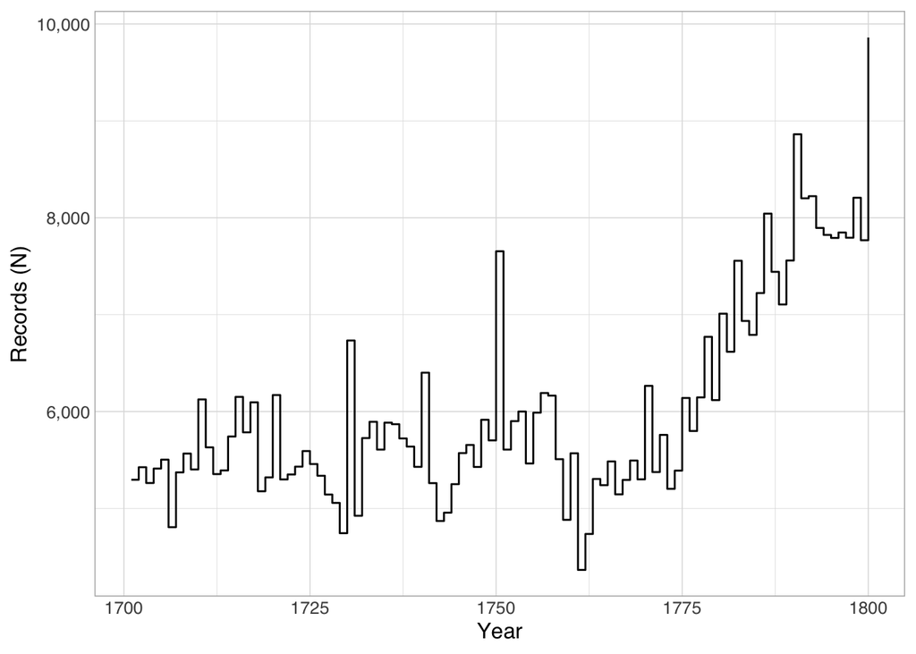

1,905 records do not have easily parseable dates between the years 1701 and 1800.

## Language overview

| [] | Records (N) | Proportion (%) |
| --- | --- | --- |
| ger (German) | 429061 | 0.657970121055424 |
| lat (Latin) | 182799 | 0.280324429763624 |
| fre (French) | 20754 | 0.031826504605136 |
| ita (Italian) | 4634 | 0.00710629383926956 |
| grc (Greek, Ancient (to 1453)) | 4632 | 0.00710322681560134 |
| heb (Hebrew) | 3730 | 0.00571999914123337 |
| eng (English) | 1204 | 0.00184634824826943 |
| yid (Yiddish) | 842 | 0.00129121696432131 |
| gre (Greek, Modern (1453-)) | 775 | 0.00118847167143589 |
| nds (Low German; Low Saxon; German, Low; Saxon, Low) | 408 | 0.000625672828317216 |

[output cut: 62 more lines]

# Field code usage overview

In total, 186 distinct fields are used.

Legend for the table below:

- `records`: how many records have at least one of this field
- `r_p`: the above as a percentage of all records
- `n`: the total number of appearances of this field
- `vals_per_rec`: calculated from the above, the mean number of appearances of this field per record
- `recs_with_mult_vals`: the number of records that have more than one repetition of this field

| field_code | field_description | records | r_p | n | vals_per_rec | recs_with_mult_vals |
| --- | --- | --- | --- | --- | --- | --- |
| <a name="001@" href="https://swbtools.bsz-bw.de/cgi-bin/k10plushelp.pl?cmd=kat&val=0000">001@</a> | ILN-bits, supplier code a.o. | 3134 | 0.00512905279454821 | 3134 | 1 | 0 |
| <a name="001A" href="https://swbtools.bsz-bw.de/cgi-bin/k10plushelp.pl?cmd=kat&val=0200">001A</a> | Kennung und Datum der Ersterfassung | 611029 | 1 | 611029 | 1 | 0 |
| <a name="001B" href="https://swbtools.bsz-bw.de/cgi-bin/k10plushelp.pl?cmd=kat&val=0210">001B</a> | Kennung und Datum der letzten Änderung | 611029 | 1 | 1222058 | 2 | 611029 |
| <a name="001D" href="https://swbtools.bsz-bw.de/cgi-bin/k10plushelp.pl?cmd=kat&val=0230">001D</a> | Kennung und Datum der Statusänderung | 611029 | 1 | 611029 | 1 | 0 |
| <a name="001U" href="https://swbtools.bsz-bw.de/cgi-bin/k10plushelp.pl?cmd=kat&val=000K">001U</a> | Characterset | 611029 | 1 | 611034 | 1.00000818291767 | 5 |
| <a name="001X" href="https://swbtools.bsz-bw.de/cgi-bin/k10plushelp.pl?cmd=kat&val=000A">001X</a> | Owner main record | 611029 | 1 | 611029 | 1 | 0 |
| <a name="002@" href="https://swbtools.bsz-bw.de/cgi-bin/k10plushelp.pl?cmd=kat&val=0500">002@</a> | Bibliografische Gattung und Status | 611029 | 1 | 611029 | 1 | 0 |
| <a name="002C" href="https://swbtools.bsz-bw.de/cgi-bin/k10plushelp.pl?cmd=kat&val=0501">002C</a> | Inhaltstyp | 609354 | 0.997258722581089 | 1219544 | 2.00137194471522 | 609351 |
| <a name="002D" href="https://swbtools.bsz-bw.de/cgi-bin/k10plushelp.pl?cmd=kat&val=0502">002D</a> | Medientyp | 609382 | 0.997304546920032 | 1220808 | 2.00335421787975 | 609382 |
| <a name="002E" href="https://swbtools.bsz-bw.de/cgi-bin/k10plushelp.pl?cmd=kat&val=0503">002E</a> | Datenträgertyp | 609382 | 0.997304546920032 | 1220930 | 2.00355442070819 | 609380 |

[output cut: 176 more lines]

# Field code usage overview by subfield

In total, 1,205 distinct field+subfield combinations are used.

Legend for the table below:

- `records`: how many records have at least one of this field+subfield
- `r_p`: the above as a percentage of all records
- `dist_vals`: the number of different values appearing in this field+subfield
- `e_vals`: at most seven random sample values of this field+subfield
- `n`: the total number of appearances of this field+subfield
- `vals_per_rec`: calculated from the above, the mean number of appearances of this field+subfield per record
- `recs_with_mult_vals`: the number of records that have more than one repetition of this field+subfield

| subfield_code | subfield_description | records | r_p | dist_vals | e_vals | n | vals_per_rec | recs_with_mult_vals |
| --- | --- | --- | --- | --- | --- | --- | --- | --- |
| [001@: ILN-bits, supplier code a.o.](https://swbtools.bsz-bw.de/cgi-bin/k10plushelp.pl?cmd=kat&val=0000) |  |  |  |  |  |  |  |  |
| 001@$0 | ILN-bits, userbits | 3,134 | 0.51% | 1 | 1 (3134) | 3,134 | 1 | 0 |
| [001A: Kennung und Datum der Ersterfassung](https://swbtools.bsz-bw.de/cgi-bin/k10plushelp.pl?cmd=kat&val=0200) |  |  |  |  |  |  |  |  |
| 001A$0 | Kennung und Datum der Ersterfassung | 611,029 | 100% | 484 | 8112:28-05-21 (1)\|8112:11-01-21 (2)\|8112:13-10-21 (1)\|8112:22-09-11 (5)\|8112:21-06-12 (1)\|8112:13-10-14 (3984)\|8112:22-07-21 (1) | 611,029 | 1 | 0 |
| [001B: Kennung und Datum der letzten Änderung](https://swbtools.bsz-bw.de/cgi-bin/k10plushelp.pl?cmd=kat&val=0210) |  |  |  |  |  |  |  |  |
| 001B$0 | Kennung und Datum | 611,029 | 100% | 130 | 2049:27-03-24 (2)\|2049:14-10-22 (91)\|1999:25-02-25 (1878)\|2049:28-06-21 (2)\|1999:04-10-21 (284)\|1999:08-02-23 (3)\|2049:26-05-23 (2) | 611,029 | 1 | 0 |
| 001B$t | Uhrzeit | 611,029 | 100% | 57,103 | 01:58:17.000 (2)\|03:58:58.000 (18)\|13:26:17.000 (1)\|10:49:31.000 (2)\|08:03:48.000 (1)\|03:16:57.000 (22)\|03:21:53.000 (4) | 611,029 | 1 | 0 |
| [001D: Kennung und Datum der Statusänderung](https://swbtools.bsz-bw.de/cgi-bin/k10plushelp.pl?cmd=kat&val=0230) |  |  |  |  |  |  |  |  |
| 001D$0 | Kennung und Datum | 611,029 | 100% | 187 | 2049:28-02-23 (7)\|1999:08-05-25 (212)\|2049:22-11-17 (13)\|1999:21-12-17 (1162)\|1999:07-08-20 (8)\|2049:27-03-23 (978)\|2049:07-06-18 (3530) | 611,029 | 1 | 0 |
| [001U: Characterset](https://swbtools.bsz-bw.de/cgi-bin/k10plushelp.pl?cmd=kat&val=000K) |  |  |  |  |  |  |  |  |
| 001U$0 | Unicode-Kennzeichen | 611,029 | 100% | 1 | utf8 (611034) | 611,034 | 1 | 5 |
| [001X: Owner main record](https://swbtools.bsz-bw.de/cgi-bin/k10plushelp.pl?cmd=kat&val=000A) |  |  |  |  |  |  |  |  |
| 001X$0 | Owner | 611,029 | 100% | 1 | 0 (611029) | 611,029 | 1 | 0 |
| [002@: Bibliografische Gattung und Status](https://swbtools.bsz-bw.de/cgi-bin/k10plushelp.pl?cmd=kat&val=0500) |  |  |  |  |  |  |  |  |
| 002@$0 | Bibliografische Gattung und Status | 611,029 | 100% | 17 | Obv (3965)\|Avv (3645)\|Odv (43)\|Oav (242483)\|Adv (58)\|Ocv (11442)\|OFv (1816) | 611,029 | 1 | 0 |
| [002C: Inhaltstyp](https://swbtools.bsz-bw.de/cgi-bin/k10plushelp.pl?cmd=kat&val=0501) |  |  |  |  |  |  |  |  |
| 002C$X | Zuordnung | 1 | 0% | 1 | 1 (1) | 1 | 1 | 0 |
| 002C$a | Inhaltstyp in ausgeschriebener Form | 609,354 | 99.73% | 5 | Noten (280)\|Computerdaten (4)\|unbewegtes Bild (386)\|Text (609073)\|kartografisches Bild (30) | 609,773 | 1 | 419 |
| 002C$b | Inhaltstyp in codierter Form | 609,351 | 99.73% | 5 | cod (4)\|cri (30)\|sti (386)\|txt (609070)\|ntm (280) | 609,770 | 1 | 419 |
| [002D: Medientyp](https://swbtools.bsz-bw.de/cgi-bin/k10plushelp.pl?cmd=kat&val=0502) |  |  |  |  |  |  |  |  |
| 002D$a | Medientyp in ausgeschriebener Form | 609,382 | 99.73% | 5 | ohne Hilfsmittel zu benutzen (312700)\|Computermedien (296681)\|nicht spezifiziert (3)\|Mikroform (1019)\|audio (1) | 610,404 | 1 | 1,022 |
| 002D$b | Medientyp in codierter Form | 609,382 | 99.73% | 5 | h (1019)\|c (296681)\|s (1)\|z (3)\|n (312700) | 610,404 | 1 | 1,022 |
| [002E: Datenträgertyp](https://swbtools.bsz-bw.de/cgi-bin/k10plushelp.pl?cmd=kat&val=0503) |  |  |  |  |  |  |  |  |
| 002E$a | Datenträgertyp in ausgeschriebener Form | 609,382 | 99.73% | 7 | Mikrofilmrolle (165)\|Blatt (12438)\|Mikrofiche (790)\|Karte (2)\|Sonstige Mikroformen (102)\|Online-Ressource (296681)\|Band (300288) | 610,466 | 1 | 1,046 |
| 002E$b | Datenträgertyp in codierter Form | 609,380 | 99.73% | 7 | cr (296681)\|no (2)\|he (790)\|nc (300352)\|hz (102)\|nb (12372)\|hj (165) | 610,464 | 1 | 1,046 |
| [003@: Pica-Produktionsnummer](https://swbtools.bsz-bw.de/cgi-bin/k10plushelp.pl?cmd=kat&val=0100) |  |  |  |  |  |  |  |  |
| 003@$0 | Pica-Produktionsnummer | 611,029 | 100% | 611,029 | 026814439 (1)\|005957494 (1)\|026933896 (1)\|026495899 (1)\|02448640X (1)\|006147836 (1)\|005330599 (1) | 611,029 | 1 | 0 |
| [003D: PPN des umgelenkten GBV- bzw. K10plus-Satzes](https://swbtools.bsz-bw.de/cgi-bin/k10plushelp.pl?cmd=kat&val=2119) |  |  |  |  |  |  |  |  |
| 003D$0 | PPN | 1 | 0% | 1 | 007468342 (1) | 1 | 1 | 0 |
| [003H: hebis-Pica-Produktionsnummer](https://swbtools.bsz-bw.de/cgi-bin/k10plushelp.pl?cmd=kat&val=0120) |  |  |  |  |  |  |  |  |

[output cut: 1361 more lines]